# 291 HW4

# Q12 Answer: The interaction term (Father:Mother) is not significant at the 0.05 level (p-value = 0.222).

```r
# When father's height is 68 inches
Q13_1 <- data.frame(Father = 68, Mother = 64)
predict(model_interaction, Q13_1 = Q13_1, se.fit = TRUE)
```

[output not shown]

[output cut: 309 more lines]

[output not shown]

```r
# 0.03731 + 68 * -2.04282 = -138.8744

## increment 4.0857

# When father's height is 70 inches
Q13_2 <- data.frame(Father = 70, Mother = 64)
predict(model_interaction, Q13_2 = Q13_2, se.fit = TRUE)
```

[output not shown]

[output cut: 309 more lines]

[output not shown]

```r
# 0.03731 + 70 * -2.04282 = -142.9601

# increment 4.0856

# When father's height is 72 inches
Q13_3 <- data.frame(Father = 72, Mother = 64)
predict(model_interaction, Q13_3 = Q13_3, se.fit = TRUE)
```

[output not shown]

[output cut: 309 more lines]

[output not shown]

```r
# 0.03731 + 72 * -2.04282 = -147.0457
```

# Q13 Answer: The increments are slightly different but the interaction term is not significant, so these differences are not statistically significant.

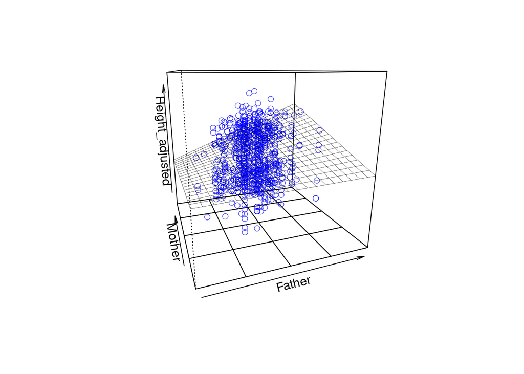

```r
library(rockchalk)
library(rsm)
# Regression plane with interaction term
plotPlane(model_interaction, plotx1 = "Father", plotx2 = "Mother", zlab = "Child's Height (Adjusted)")
```

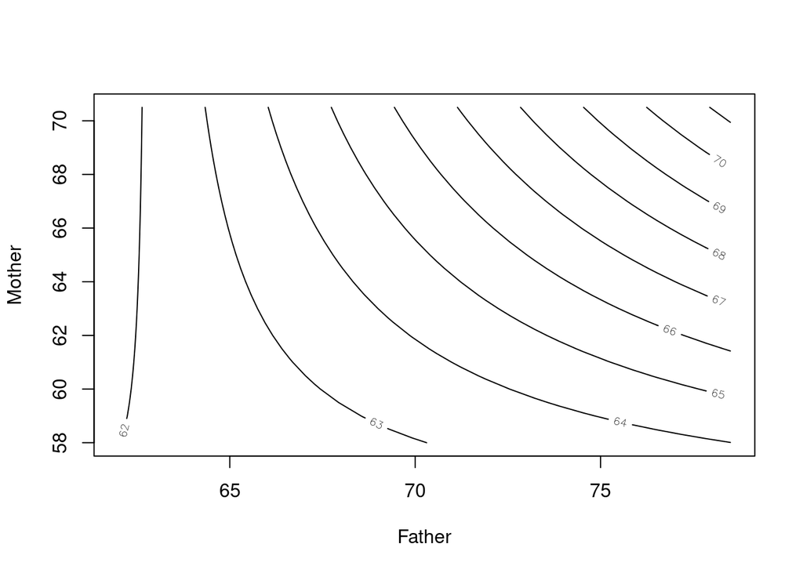

```r
contour(model_interaction, ~ Father * Mother, data = galton, zlab = "Child's Height (Adjusted)")
```

# Q15 Answer: I would choose the model without the interaction term (Q9). The model without the interaction term (Q9) is simpler with equal explanatory power as the model with the interaction term. Since the Q9 is simpler, it is preffered. It assumes that the effects of the father’s height and the mother’s height on the child’s height are additive and independent of each other.

# While the model with the interaction term (Q12) shows a slight curvature in the regression surface, this curvature is not significant enough to justify the added complexity of the model.

| # PART 3: Regression of child’s height on father and mother’s height and gender |
| --- |

```r
# Regression model of raw data, no interaction
model_no_interaction <- lm(Height ~ Father + Mother + Gender, data = galton)
summary(model_no_interaction)
```

```
##
## Call:
## lm(formula = Height ~ Father + Mother + Gender, data = galton)
##
## Residuals:
##    Min     1Q Median     3Q    Max
## -9.523 -1.440  0.117  1.473  9.114
##
## Coefficients:
##             Estimate Std. Error t value Pr(>|t|)
## (Intercept) 15.34476    2.74696   5.586 3.08e-08 ***
## Father       0.40598    0.02921  13.900  < 2e-16 ***
## Mother       0.32150    0.03128  10.277  < 2e-16 ***
## GenderM      5.22595    0.14401  36.289  < 2e-16 ***
## ---
## Signif. codes:  0 '***' 0.001 '**' 0.01 '*' 0.05 '.' 0.1 ' ' 1
##
## Residual standard error: 2.154 on 894 degrees of freedom
## Multiple R-squared:  0.6397, Adjusted R-squared:  0.6385
## F-statistic:   529 on 3 and 894 DF,  p-value: < 2.2e-16
```

```r
# All independent variables (Father, Mother, and Gender) are highly significant (p-value < 0.001).
```

# Q16 Answer:

# The coefficients for each variable are:

# Father: 0.40598

# Mother: 0.32150

# GenderM: 5.22595 (This is the average height difference between males and females)

```r
# Create the MidParentHeight variable
galton$MidParentHeight <- (galton$Father + galton$Mother * 1.08) / 2

# Run the model with MidParentHeight and Gender
model_midparent <- lm(Height ~ MidParentHeight + Gender, data = galton)
summary(model_midparent)
```

```
##
## Call:
## lm(formula = Height ~ MidParentHeight + Gender, data = galton)
##
## Residuals:
##     Min      1Q  Median      3Q     Max
## -9.5332 -1.4406  0.1003  1.4383  9.1013
##
## Coefficients:
##                 Estimate Std. Error t value Pr(>|t|)
## (Intercept)     15.40301    2.75523    5.59 3.01e-08 ***
## MidParentHeight  0.70282    0.03973   17.69  < 2e-16 ***
## GenderM          5.22817    0.14444   36.20  < 2e-16 ***
## ---
## Signif. codes:  0 '***' 0.001 '**' 0.01 '*' 0.05 '.' 0.1 ' ' 1
##
## Residual standard error: 2.161 on 895 degrees of freedom
## Multiple R-squared:  0.6371, Adjusted R-squared:  0.6363
## F-statistic: 785.5 on 2 and 895 DF,  p-value: < 2.2e-16
```

# Q17 Answer:

#The coefficients for MidParentHeight and Gender are: # MidParentHeight: 0.70282 # GenderM: 5.22817

# Q16 vs. Q17 Comparison:

# The reason for the difference in coefficients for Father and Mother vs. MidParentHeight is that the MidParentHeight formula applies a weight of 1.08 to the mother’s height before taking the average with the father’s height.

# This accounts for the mother’s height having a slightly different impact on the child’s height compared to the father’s height. By using the MidParentHeight formula, this weight is implicitly incorporated into the model, whereas in the model without interaction (Q16), the weights for Father and Mother are estimated separately.

# However, the coefficient for GenderM is the same in both models, as it represents the average height difference between males and females, despite the inclusion of MidParentHeight or separate Father and Mother variables.